# B16 · AutoGrable: selecting or declining a graph

**Skill:** choose a column-induced graph using permitted training/validation information, including the empty construction. [Lesson](https://avistian.github.io/relational/lessons/b16-autograble-graph-selection.html).

**Mirror scope:** implement the block predictor, occupancy score, exhaustive oracle, Algorithm 1 search, typed incidence constructor and actual colour refinement from [AutoGrable v1](https://arxiv.org/html/2608.11431v1). Three live TODOs with immediate CHECKs. Full visible code, Python standard library, no repository imports or package installs needed. Complete finite diagnostic only; the 400-run Adult Table 1 reproduction is blocked by missing source protocol. No GNN training is necessary for RQ1, and none is claimed here.

## Concept recap

A partition groups rows agreeing on selected columns. Selecting A with four zeros and four ones creates two blocks. The block predictor estimates the fraction of training labels equal to one in each block. A new validation key uses the training marginal, not a memorized label.

The occupancy Ω=sum(sqrt(n_b))/n penalizes tiny blocks. Eight rows in one block give 0.354; two equal blocks give 0.5; eight singleton blocks give 1. J is validation risk plus λΩ. We use binary Brier risk, the average of (p−y)², as a course choice. At λ=0.5, signal A scores 0.250 and unseen keys score 0.750.

Forward search only adds a column when J improves; backward removes columns. XOR requires A and B together. A or B alone can worsen J, trapping forward search before the useful pair. Empty is a legitimate output: rows may still have features even with no cross-row edges.

A graph’s initial features matter. With erased row features and typed value identities, stable row colours equal the projection groups. Hide value identity and symmetric stars collapse. Keep other row features and the full graph can distinguish more rows. Labels are not input features.

**Frozen data:** 8 train + 8 validation + 8 test rows per world; A=i//4, B=(i//2)%2, unique split-specific K. Signal y=A; XOR y=A XOR B; null y=i%2. Three λ values (0,0.5,1), all 8 subsets, three methods. Exact exhaustive ties favor fewer columns; greedy ties stop. IDs are disjoint, though A/B patterns deliberately repeat. This is a designed finite distribution, not a sampled benchmark. Float64 comparisons use tolerance 1e-12.

**Prediction before running:** which subset wins in each world at λ=0.5? Write your answer, then compare with the measured table after completing your code.

## Algorithm architecture

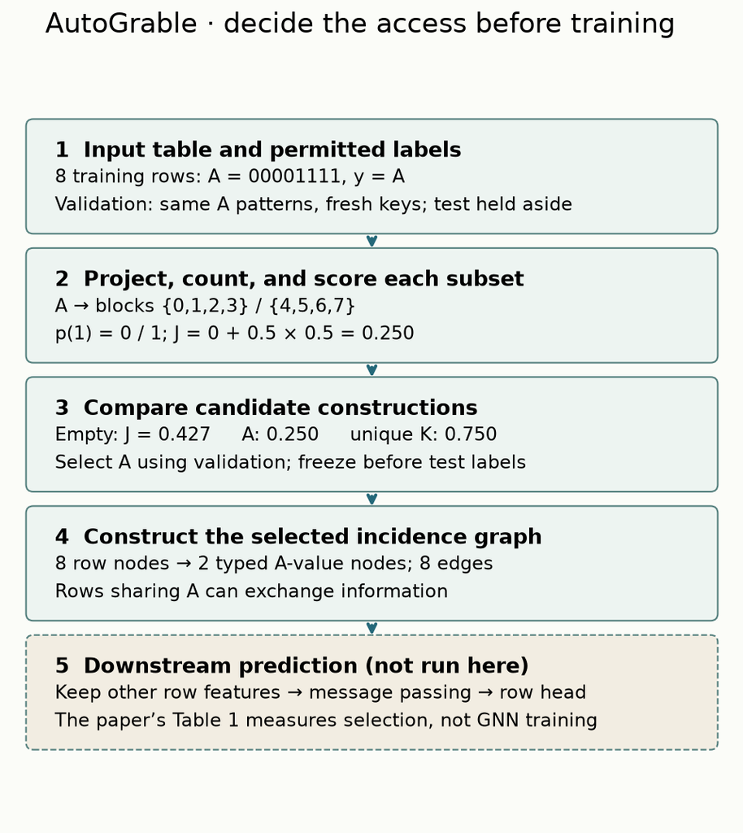

End-to-end example for signal y=A. The dashed downstream stage is explanatory and NOT_RUN. RQ1/Table 1 measures selected columns, not GNN predictive performance.

```python
# @colab-bootstrap
# Python standard library only. No installs, downloads or repository imports.
from collections import Counter, defaultdict
from itertools import combinations, product
import math
```

## PROVIDED · input contracts and exact projection

These helpers keep label/id out of the feature set and reject unsupported values. Exact typed tuples avoid silently mixing missing-value sentinels with real categories.

```python
def validate_rows(rows, labeled=True):
    """Require nonempty unique identities and finite binary labels."""
    if not rows or len({r['id'] for r in rows}) != len(rows):
        raise ValueError('Rows must be nonempty with unique ids')
    if labeled and any(r.get('y') not in (0, 1) for r in rows):
        raise ValueError('Binary labels required')

def check_columns(cols):
    if len(set(cols)) != len(cols) or any(c in ('y', 'id') for c in cols):
        raise ValueError('Distinct feature columns only; y and id are forbidden')

def projection(row, cols):
    """Exact typed tuples avoid hash collisions and missing-value sentinels."""
    check_columns(cols)
    values = []
    for c in cols:
        v = row[c]
        if type(v) not in (str, int):
            raise ValueError('Finite fixture features must be strings or integers')
        values.append((c, type(v).__name__, v))
    return tuple(values)
```

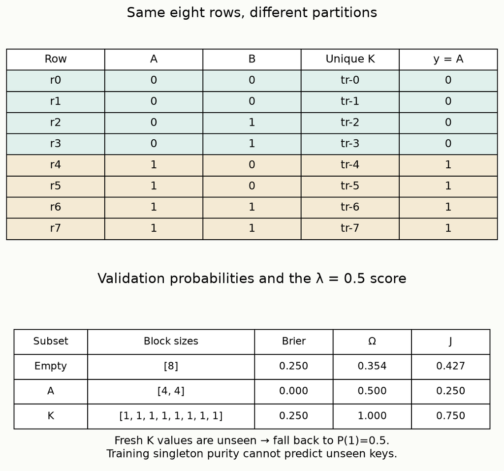

Course signal fixture. Probabilities fit training blocks; validation uses fresh K values. Decimals are rounded to three places.

## SOLUTION · block_predict

Fit only on train: group by the selected projection, divide positive labels by block count, and use the overall train proportion for unseen queries. Empty columns give one block. Query labels must never be read. Call the provided row/column validation helpers. **Why:** a unique training key must not reveal a new row’s label.

```python
def block_predict(train, query, cols):
    """Eq.1 block predictor: train cell means, train marginal for unseen cells."""
    validate_rows(train)
    check_columns(cols)
    counts, positives = Counter(), Counter()
    for row in train:
        key = projection(row, cols)
        counts[key] += 1
        positives[key] += row['y']
    marginal = sum(r['y'] for r in train) / len(train)
    return [positives[key] / counts[key] if counts[key] else marginal
            for key in (projection(row, cols) for row in query)]
```

### CHECK · block_predict

Run now; fix the input/counting error before continuing.

```python
tr=[dict(id='a',A=0,y=0),dict(id='b',A=0,y=1),dict(id='c',A=1,y=1)]
assert block_predict(tr,[dict(A=0),dict(A=1),dict(A=2)],['A'])==[.5,1,2/3], 'Seen cells need train proportions; unseen needs train marginal'
assert block_predict(tr,[dict(A=99)],[])==[2/3]
print('Block prediction CHECK passed')
```

```
Block prediction CHECK passed
```

## SOLUTION · occupancy

Validate a nonempty list of positive integer sizes; return sum(sqrt(size))/sum(size). **Why:** perfect training purity can be purchased by fragmenting every row. Derive the one-block and singleton extremes before coding.

```python
def occupancy(sizes):
    """Eq.1: training fragmentation ranges from 1/sqrt(n) to 1."""
    if not sizes or any(type(n) is not int or n <= 0 for n in sizes):
        raise ValueError('Positive integer block sizes required')
    return sum(math.sqrt(n) for n in sizes) / sum(sizes)
```

### CHECK · occupancy

Run now; fix the input/counting error before continuing.

```python
assert abs(occupancy([8])-1/math.sqrt(8))<1e-12
assert occupancy([4,4])==.5
assert occupancy([1]*8)==1
try: occupancy([0])
except ValueError: pass
else: raise AssertionError('Reject nonpositive block sizes')
print('Occupancy CHECK passed')
```

```
Occupancy CHECK passed
```

## PROVIDED · score each candidate (Eq.1)

Brier loss is the course default. The optional 0–1 and clipped-log losses permit narrow upstream scoring comparisons; they do not establish the loss used in Table 1. The scorer calls your live block_predict and occupancy functions.

```python
def loss_value(probabilities, labels, loss='brier'):
    if not probabilities or len(probabilities) != len(labels):
        raise ValueError('Aligned nonempty probabilities and labels required')
    if any(y not in (0, 1) for y in labels) or any(not math.isfinite(p) or not 0 <= p <= 1 for p in probabilities):
        raise ValueError('Invalid binary probability or label')
    if loss == 'brier':
        return sum((p-y)**2 for p,y in zip(probabilities, labels)) / len(labels)
    if loss == '0-1':
        # Fixed label-0 tie break, unlike upstream first-observed class order.
        return sum(int(p > .5) != y for p,y in zip(probabilities, labels)) / len(labels)
    if loss == 'logloss':
        return -sum(math.log(max(1e-12, p if y else 1-p)) for p,y in zip(probabilities, labels)) / len(labels)
    raise ValueError('Unknown loss')

def score_subset(train, valid, cols, penalty=0.5, loss='brier'):
    validate_rows(train)
    validate_rows(valid)
    if {r['id'] for r in train} & {r['id'] for r in valid}:
        raise ValueError('Training and validation identities overlap')
    if not math.isfinite(penalty) or penalty < 0:
        raise ValueError('Finite nonnegative penalty required')
    probabilities = block_predict(train, valid, cols)
    sizes = list(Counter(projection(r, cols) for r in train).values())
    risk = loss_value(probabilities, [r['y'] for r in valid], loss)
    omega = occupancy(sizes)
    return dict(cols=list(cols), sizes=sizes, probabilities=probabilities,
                risk=risk, omega=omega, J=risk + penalty * omega)

def subsets(candidates):
    return [list(s) for k in range(len(candidates)+1) for s in combinations(candidates, k)]
```

## SOLUTION · select_columns

Return a dictionary with selected, J and trace. Score with score_subset; enumerate with subsets for the exhaustive method. Break exhaustive ties by fewer columns then lexical order (within tolerance); greedy moves inspect sorted candidates and require improvement > tolerance. Start empty/full for forward/backward; permit removing the last column. Record considered moves and accepted states. **Why:** the same objective can have different search outcomes. Pseudocode: initialize → score every one-column neighbor → choose the best → accept only strict improvement → repeat.

```python
def select_columns(train, valid, candidates, penalty=0.5, method='exhaustive', tolerance=1e-12):
    """Algorithm 1 with strict improvement and backward access to empty set.

    All scoring calls use train/validation only. Exhaustive search is the finite
    oracle, not a scalable proposal. Candidate order fixes greedy move ties.
    """
    check_columns(candidates)
    if method not in ('exhaustive', 'forward', 'backward') or not math.isfinite(tolerance) or tolerance < 0:
        raise ValueError('Invalid method or tolerance')
    candidates = sorted(candidates)
    if method == 'exhaustive':
        scores = [score_subset(train, valid, s, penalty) for s in subsets(candidates)]
        minimum = min(s['J'] for s in scores)
        best = next(s for s in scores if s['J'] <= minimum + tolerance)
        return dict(selected=best['cols'], J=best['J'], trace=scores)
    current = candidates[:] if method == 'backward' else []
    value = score_subset(train, valid, current, penalty)
    trace = [dict(selected=current[:], J=value['J'], action='init')]
    while True:
        moves = ([c for c in candidates if c not in current] if method == 'forward' else current)
        if not moves:
            break
        options = [score_subset(train, valid,
                    sorted(current+[c]) if method == 'forward' else [x for x in current if x != c], penalty)
                   for c in moves]
        best = min(options, key=lambda s:s['J'])
        improvement = value['J'] - best['J']
        accepted = improvement > tolerance
        trace.append(dict(proposed=best['cols'], J=best['J'], improvement=improvement,
                          action='accept' if accepted else 'stop', considered=options))
        if not accepted:
            break
        current, value = best['cols'], best
    return dict(selected=current, J=value['J'], trace=trace)
```

### CHECK · search path and abstention

Reject implementations that return a fixed answer, choose test scores, or stop backward at one column.

```python
tr=[dict(id=f'tr-{i}',A=i//4,B=(i//2)%2,y=(i//4)^((i//2)%2)) for i in range(8)]
va=[dict(r,id=r['id'].replace('tr','va')) for r in tr]
assert select_columns(tr,va,['A','B'],.5,'forward')['selected']==[]
assert select_columns(tr,va,['A','B'],.5,'backward')['selected']==['A','B']
assert select_columns(tr,va,['A','B'],.5,'exhaustive')['selected']==['A','B']
assert select_columns(tr,va,['A','B'],1,'backward')['selected']==['A','B'], 'Backward also has a local trap at lambda=1'
assert select_columns(tr,va,['A','B'],1,'exhaustive')['selected']==[]
null_train=[dict(r,y=i%2) for i,r in enumerate(tr)]
null_valid=[dict(r,id=r['id'].replace('tr','va')) for r in null_train]
assert select_columns(null_train,null_valid,['A','B'],.5,'backward')['selected']==[], 'Null case must permit removing the last column'
print('Search CHECK passed')
```

```
Search CHECK passed
```

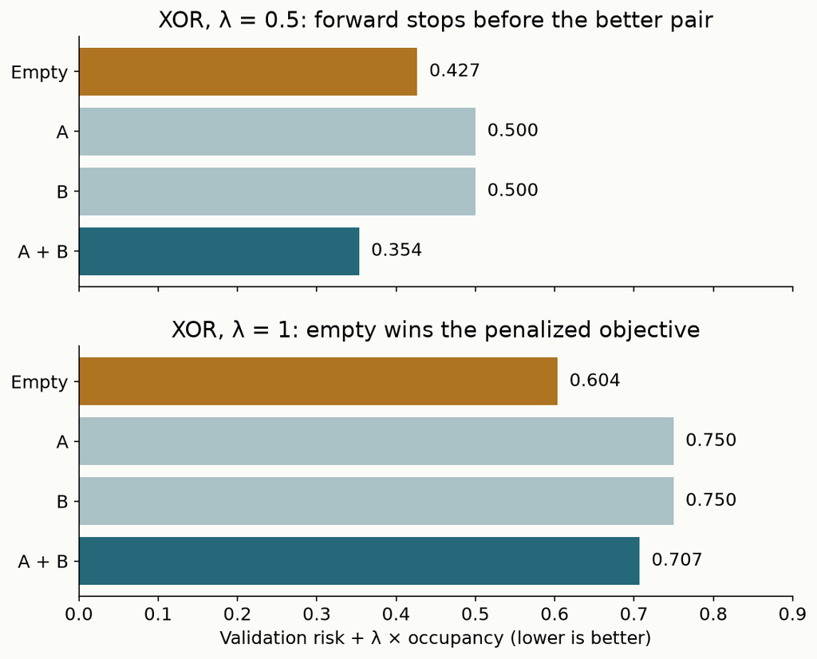

Finite XOR scores with Brier loss. At λ=0.5 the pair is the best objective but forward cannot reach it. At λ=1 abstention is the objective optimum. The vertical order is fixed across panels.

## PROVIDED · build the graph and run colour refinement

Each row connects to its selected typed values. A signature contains own colour plus a multiset of typed neighbor colours. Intern signatures injectively until no further splitting occurs. In this finite refinement, equal block count implies stabilization because old colours are retained. Never compare arbitrary colour IDs across separately interned graphs.

```python
def incidence_graph(rows, cols, typed_values=True, row_features=()):
    """Section 4 incidence construction. Labels and row IDs are not features.

    Each undirected edge is stored twice with its column type. A value node is
    shared exactly when the column and literal value agree. typed_values=False
    deliberately removes literal identity, illustrating the lemma's assumption.
    """
    validate_rows(rows, labeled=False)
    check_columns(cols)
    check_columns(row_features)
    if set(cols) & set(row_features):
        raise ValueError('Row-local features must be unexpanded columns')
    colors = [('row', projection(r, row_features)) for r in rows]
    neighbors = [[] for _ in rows]
    value_nodes = {}
    for i, row in enumerate(rows):
        for c in cols:
            key = projection(row, [c])
            if key not in value_nodes:
                j = len(colors)
                value_nodes[key] = j
                colors.append(('value', key if typed_values else c))
                neighbors.append([])
            j = value_nodes[key]
            neighbors[i].append((c,j))
            neighbors[j].append((c,i))
    return colors, neighbors

def color_refinement(colors, neighbors):
    """Injective tuple interning; iterate until the equality partition stabilizes."""
    def intern(signatures):
        dictionary = {}
        return [dictionary.setdefault(s, len(dictionary)) for s in signatures]
    state = intern(colors)
    for _ in range(len(state)):
        signatures = [(state[i], tuple(sorted((edge,state[j]) for edge,j in adj)))
                      for i, adj in enumerate(neighbors)]
        new = intern(signatures)
        # Refinement retains old colors, so unchanged block count means stability.
        if len(set(new)) == len(set(state)):
            return new
        state = new
    raise AssertionError('Finite refinement failed to stabilize')

def incidence_partition(rows, cols, typed_values=True, row_features=()):
    colors, neighbors = incidence_graph(rows, cols, typed_values, row_features)
    state = color_refinement(colors, neighbors)
    blocks = defaultdict(list)
    for i, color in enumerate(state[:len(rows)]):
        blocks[color].append(i)
    return sorted(blocks.values(), key=lambda b:b[0])
```

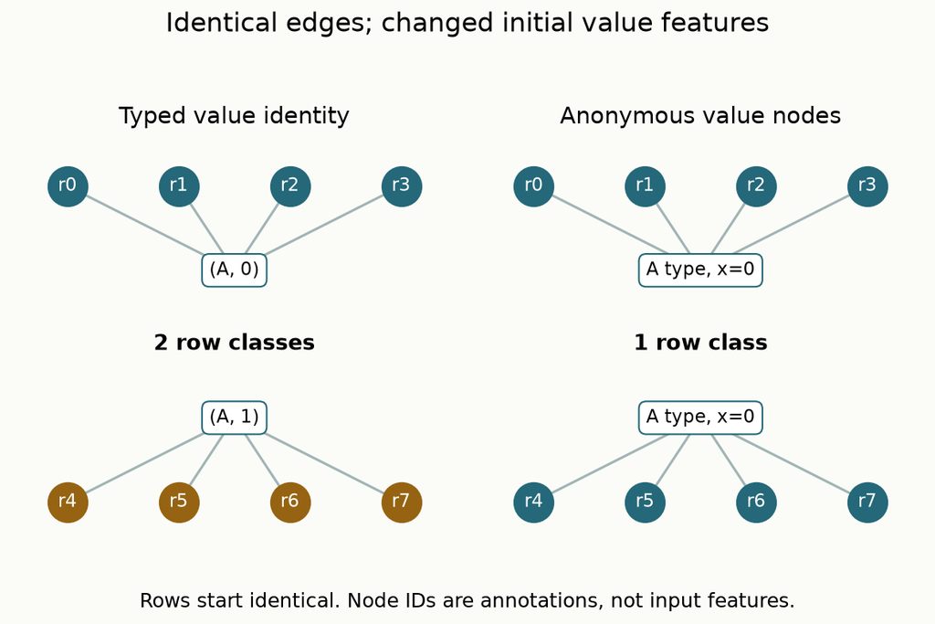

Actual edge pattern for A selected. Both panels erase row features. Changing initial value identity changes the row partition even though edges are identical. Row numbers are annotations, not model features.

## PROVIDED · complete finite generator and frozen evaluation

The generator has no randomness and no hidden optimizer. The evaluation pipeline selects before test labels are scored. All 256 binary test-label vectors are interventions: labels may change reported loss, but never selected columns or probabilities. These functions call your live implementations.

```python
def fixture(kind='signal', prefix='tr'):
    if kind not in ('signal', 'xor', 'null'):
        raise ValueError('Unknown fixture')
    return [dict(id=f'{prefix}-{i}', A=i//4, B=(i//2)%2, K=f'{prefix}-{i}',
                 y=i//4 if kind=='signal' else ((i//4)^((i//2)%2) if kind=='xor' else i%2)) for i in range(8)]

def evaluate_frozen(train, valid, test, candidates, penalty, method):
    """Selection is frozen before reading test labels; save row-keyed predictions."""
    validate_rows(test)
    ids = [r['id'] for rows in (train,valid,test) for r in rows]
    if len(set(ids)) != len(ids):
        raise ValueError('Split identities overlap')
    selected = select_columns(train, valid, candidates, penalty, method)
    features = [{k:v for k,v in r.items() if k != 'y'} for r in test]
    probabilities = block_predict(train, features, selected['selected'])
    predictions = [dict(id=r['id'], probability=p, label=r['y']) for r,p in zip(test, probabilities)]
    return dict(**selected, predictions=predictions,
                test_brier=loss_value(probabilities, [r['y'] for r in test]))

def run_experiment():
    """The complete frozen course grid; no randomness or hidden model fits."""
    candidates = ['A','B','K']
    report = dict(experiment='B16-PARTITION-SELECTION', scope='COMPLETE_FINITE_DIAGNOSTIC',
                  datasets={}, subsets=[], selections=[], graph_checks=[], test_interventions=[])
    for kind in ('signal','xor','null'):
        train, valid, test = [fixture(kind, split) for split in ('tr','va','te')]
        report['datasets'][kind] = dict(train=train, valid=valid, test=test)
        for cols in subsets(candidates):
            graph_blocks = incidence_partition(train, cols)
            groups = defaultdict(list)
            for i, row in enumerate(train):
                groups[projection(row, cols)].append(i)
            expected = sorted(groups.values(), key=lambda b:b[0])
            assert graph_blocks == expected
            report['graph_checks'].append(dict(world=kind,cols=cols,blocks=graph_blocks))
        for penalty in (0, .5, 1):
            for cols in subsets(candidates):
                report['subsets'].append(dict(world=kind, penalty=penalty, **score_subset(train,valid,cols,penalty)))
            for method in ('exhaustive','forward','backward'):
                result = evaluate_frozen(train,valid,test,candidates,penalty,method)
                report['selections'].append(dict(world=kind,penalty=penalty,method=method,**result))
    train, valid, test = [fixture('signal', split) for split in ('tr','va','te')]
    base = evaluate_frozen(train, valid, test, candidates, .5, 'exhaustive')
    for labels in product((0,1), repeat=8):
        changed = [dict(row,y=y) for row,y in zip(test,labels)]
        result = evaluate_frozen(train,valid,changed,candidates,.5,'exhaustive')
        unchanged = (result['selected']==base['selected'] and result['trace']==base['trace'] and
                     [r['probability'] for r in result['predictions']]==[r['probability'] for r in base['predictions']])
        report['test_interventions'].append(dict(labels=list(labels),unchanged=unchanged))
    report['feature_boundary'] = dict(typed=incidence_partition(train,['A']),
        anonymous=incidence_partition(train,['A'],False), full=incidence_partition(train,['A'],True,['B']))
    return report
```

## RUN · full finite grid

Expected coverage: 72 subset scores, 27 selections, 24 graph checks and 256 test-label interventions. The following table is produced by your live functions, not a pasted author result.

```python
report=run_experiment()
assert len(report['subsets'])==72 and len(report['selections'])==27
assert len(report['graph_checks'])==24 and len(report['test_interventions'])==256
assert all(r['unchanged'] for r in report['test_interventions'])
print(f"{'World':9} {'Method':11} {'Selected':12} {'J':>7} {'Test Brier':>11}")
for row in report['selections']:
    if row['penalty']==.5:
        selected='+'.join(row['selected']) or 'empty'
        print(f"{row['world']:9} {row['method']:11} {selected:12} {row['J']:7.3f} {row['test_brier']:11.3f}")
import json
from pathlib import Path
Path('b16-diagnostic.json').write_text(json.dumps(report,indent=2,sort_keys=True)+'\n')
```

```
World     Method      Selected           J  Test Brier
signal    exhaustive  A              0.250       0.000
signal    forward     A              0.250       0.000
signal    backward    A              0.250       0.000
xor       exhaustive  A+B            0.354       0.000
xor       forward     empty          0.427       0.250
xor       backward    A+B            0.354       0.000
null      exhaustive  empty          0.427       0.250
null      forward     empty          0.427       0.250
null      backward    empty          0.427       0.250
```

```
192801
```

## EXIT · explain the mechanism

Write 150–200 words: separate objective failure from search failure in XOR; explain unseen-key fallback; state the lemma’s two feature assumptions; explain why no test label may choose the graph. Include one source discrepancy and its implication. Ask the teacher for feedback. Revisit after 1/7/30 days. Author execution is not learner mastery.

```python
assert report['feature_boundary']==dict(typed=[[0,1,2,3],[4,5,6,7]],anonymous=[list(range(8))],full=[[0,1],[2,3],[4,5],[6,7]])
print('B16-PARTITION-SELECTION: COMPLETE_FINITE_DIAGNOSTIC')
print('B16-AUTOGRABLE-TABLE1: INCOMPLETE_SOURCE_PROTOCOL_GATE; execution NOT_RUN')
print('Learner: PENDING_WRITTEN_DEFENSE')
```

```
B16-PARTITION-SELECTION: COMPLETE_FINITE_DIAGNOSTIC
B16-AUTOGRABLE-TABLE1: INCOMPLETE_SOURCE_PROTOCOL_GATE; execution NOT_RUN
Learner: PENDING_WRITTEN_DEFENSE
```

## Paper-results lane · inspect the complete pinned release

**Named target:** Table 1, 5 task families × 2 encodings × 2 directions × 2 penalties × 10 seeds = 400 selection runs. Metrics are exact-recovery and recall percentages. Full target grid is retained in the contract. No fresh Table 1 run has occurred.

**Missing:** authenticated Adult/preprocessing and sample identity, seed/split recipe, planted column/value/threshold/binarization and balancing rules, actual loss/tolerance. The generic income example cannot substitute for the synthetic family generator.

**Demonstrated source differences:** backward search stops at one column; train uses train-frequency counts while validation uses union counts; actual value-node x is zero while the lemma assumes typed identity. Optional per-ID/random-hash value encoders exist in the TabArena model and are off by default; the zero-feature counterexample concerns the audited graph configuration. Source defaults are not historical experiment records. Narrow 144-case score parity on 0–1/log loss does not fix these differences. The course deliberately uses bounded Brier loss and permits backward removal to empty.

The following packet contains the complete release, paper, source hashes, executable guarded preflight, measured source audit and contract. The preflight runs from this notebook without repo access. It has no cloud dispatch. Turning on the last cell authenticates sources, then refuses the underspecified paper run. This is an executable gate, not a completed benchmark runner. The original experimental driver must be recovered before that can change.

Budget: initial USD0 cloud, USD10 total ceiling, paid stop USD8/reserve USD2. Local author numerical cap 3600 aggregate seconds; portable learner reruns are a separate execution. Other paper benchmarks NOT_RUN, historical identity NOT_ESTABLISHED, live Colab NOT_CHECKED.

```python
import base64,io,zipfile,subprocess,sys
packet=Path('b16-source-packet');packet.mkdir(exist_ok=True)
archive=zipfile.ZipFile(io.BytesIO(base64.b64decode('UEsDBBQAAAAIAKlARF14nl2JiAcAAFASAAAhAAAAc291cmNlcy9iMTYvYXV0…==')))
archive.extractall(packet)
check=subprocess.run([sys.executable,str(packet/'_reproduce_b16.py'),'--phase','audit'],capture_output=True,text=True,check=True)
print(check.stdout)
```

```
{
  "experiment": "B16-AUTOGRABLE-TABLE1",
  "status": "INCOMPLETE_SOURCE_PROTOCOL_GATE",
  "execution": "NOT_RUN",
  "planned_runs": 400,
  "executed_runs": 0,
  "commit": "1cfad48ae8d8362ad7eca10f9fe6db115004975e",
  "missing": [
    "Adult file/preprocessing identity and row sample size",
    "seed identities and row/split resampling",
    "planted column/value/threshold/binarization and balancing rules",
    "train/validation membership",
    "reported loss, tolerance and frequency-count population"
  ],
  "discrepancies": [
    "backward search stops at one column",
    "train-only versus union frequency signatures",
    "zero-feature value nodes versus typed-value identities"
  ],
  "other_paper_benchmarks": "NOT_RUN",
  "historical_identity": "NOT_ESTABLISHED",
  "cloud_usd": 0
}
Authenticated 29 source files. No model training or paid dispatch.
```

### Read the released selector beside your implementation

These are unmodified source files from the pinned release. The example above implements the paper’s backward-to-empty search; locate the conflicting stopping condition below. Full graph models/trainers are in the extracted packet; they are not required for RQ1.

#### Pinned upstream selection.py

```
from __future__ import annotations

from typing import Any, Dict, List, Optional, Tuple
import numpy as np
import pandas as pd

from .utils import omega_from_group_sizes, loss_from_proba


def build_block_probas(
    X_train: pd.DataFrame,
    y_train: pd.Series,
    cols: list[str],
) -> tuple[pd.DataFrame, pd.Series]:
    """
    Block-conditional class probabilities estimated on train.
    Uses hashed block keys to avoid MultiIndex cartesian blow-ups.
    """
    classes = pd.Index(pd.unique(y_train))
    y_cat = pd.Categorical(y_train, categories=classes)

    key = make_block_key(X_train, cols)

    # counts: rows=blocks, cols=classes
    counts = pd.crosstab(key, y_cat, dropna=False)

    # Ensure all classes are columns (in case a class is missing in train split)
    for cl in classes:
        if cl not in counts.columns:
            counts[cl] = 0
    counts = counts[classes]

    totals = counts.sum(axis=1).replace(0, 1)
    block_probas = counts.div(totals, axis=0)

    global_counts = pd.Series(y_cat).value_counts().reindex(classes, fill_value=0)
    global_proba = global_counts / max(int(global_counts.sum()), 1)

    return block_probas, global_proba


def predict_proba_from_blocks(
    X: pd.DataFrame,
    cols: list[str],
    block_probas: pd.DataFrame,
    global_proba: pd.Series,
) -> pd.DataFrame:
    """
    Lookup block probabilities using hashed keys; unseen blocks fall back to global prior.
    """
    classes = global_proba.index
    key = make_block_key(X, cols)

    mapped = block_probas.reindex(key.values)   # index of block_probas is block key
    mapped = mapped.fillna(global_proba)
    mapped.index = X.index
    mapped.columns = classes
    return mapped


def evaluate_subset(
    X_train: pd.DataFrame,
    y_train: pd.Series,
    X_val: pd.DataFrame,
    y_val: pd.Series,
    cols: List[str],
    *,
    lambda_: float,
    loss_name: str,
    omega_on: str,  # "train" or "val"
) -> Dict[str, Any]:
    block_probas, global_proba = build_block_probas(X_train, y_train, cols)

    proba_val = predict_proba_from_blocks(X_val, cols, block_probas, global_proba)
    val_loss = loss_from_proba(y_val, proba_val, loss_name=loss_name)

    if omega_on == "train":
        key_for_omega = make_block_key(X_train, cols)
    else:
        key_for_omega = make_block_key(X_val, cols)

    gsz = key_for_omega.value_counts().to_numpy()

    omega = omega_from_group_sizes(gsz)
    J = float(val_loss + lambda_ * omega)

    return {
        "cols": cols,
        "J": J,
        "val_loss": float(val_loss),
        "omega": float(omega),
        "n_blocks_train": int(block_probas.shape[0]) if cols else 1,
        "block_probas": block_probas,
        "global_proba": global_proba,
    }


def greedy_selection(
    X_train: pd.DataFrame,
    y_train: pd.Series,
    X_val: pd.DataFrame,
    y_val: pd.Series,
    initial_cols: List[str],
    *,
    direction: str = "backward",
    lambda_: float,
    loss_name: str,
    omega_on: str = "train",
    min_improvement: float = 0.0,
    max_steps: Optional[int] = None,
) -> Tuple[List[str], List[str], List[Dict[str, Any]], Dict[str, Any]]:
    """
    Greedy structural column selection, minimizing J(S) = val_loss + lambda * Omega(S).

    direction="backward": start with S = all of initial_cols (every column
        distinguishes a block) and greedily drop the column whose removal
        improves J the most, stopping when no drop improves J (by more than
        min_improvement) or when a single column remains.

    direction="forward": start with S = [] (all rows are a single block)
        and greedily add the column whose inclusion improves J the most,
        stopping when no addition improves J or every column has been added.

    Returns:
      selected_cols, unselected_cols, history, final_eval

      unselected_cols is the columns dropped (backward) or never added
      (forward).
    """
    if direction not in ("backward", "forward"):
        raise ValueError("direction must be 'backward' or 'forward'")
    if omega_on not in ("train", "val"):
        raise ValueError("omega_on must be 'train' or 'val'")

    backward = direction == "backward"

    S: List[str] = list(initial_cols) if backward else []
    pool: List[str] = [] if backward else list(initial_cols)
    unselected: List[str] = []
    history: List[Dict[str, Any]] = []

    cur = evaluate_subset(
        X_train, y_train, X_val, y_val, S,
        lambda_=lambda_, loss_name=loss_name, omega_on=omega_on
    )
    history.append({
        "step": 0,
        "action": "init",
        "cols": S.copy(),
        "J": cur["J"],
        "val_loss": cur["val_loss"],
        "omega": cur["omega"],
        "n_blocks_train": cur["n_blocks_train"],
    })

    step = 0
    while True:
        if max_steps is not None and step >= max_steps:
            break

        candidates = S if backward else pool
        if backward and len(S) <= 1:
            break
        if not backward and not pool:
            break

        best: Optional[Dict[str, Any]] = None
        best_move: Optional[str] = None

        for c in candidates:
            cand_cols = [x for x in S if x != c] if backward else S + [c]
            cand = evaluate_subset(
                X_train, y_train, X_val, y_val, cand_cols,
                lambda_=lambda_, loss_name=loss_name, omega_on=omega_on
            )
            if best is None or cand["J"] < best["J"]:
                best = cand
                best_move = c

        assert best is not None and best_move is not None
        improvement = float(cur["J"] - best["J"])
        move_key = "dropped" if backward else "added"
        move_action = "drop" if backward else "add"

        history.append({
            "step": step + 1,
            "action": move_action if improvement > min_improvement else "stop",
            move_key: best_move,
            "improvement": improvement,
            "cols": best["cols"].copy(),
            "J": best["J"],
            "val_loss": best["val_loss"],
            "omega": best["omega"],
            "n_blocks_train": best["n_blocks_train"],
        })

        if improvement <= min_improvement:
            break

        # accept
        if backward:
            unselected.append(best_move)
        else:
            pool = [x for x in pool if x != best_move]
        S = best["cols"]
        cur = best
        step += 1

    if not backward:
        unselected = [c for c in initial_cols if c not in S]

    final_eval = cur
    return S, unselected, history, final_eval


def greedy_backward_elimination(
    X_train: pd.DataFrame,
    y_train: pd.Series,
    X_val: pd.DataFrame,
    y_val: pd.Series,
    initial_cols: List[str],
    *,
    lambda_: float,
    loss_name: str,
    omega_on: str = "train",
    min_improvement: float = 0.0,
    max_steps: Optional[int] = None,
) -> Tuple[List[str], List[str], List[Dict[str, Any]], Dict[str, Any]]:
    """
    Returns:
      selected_cols, dropped_cols, history, final_eval
    """
    return greedy_selection(
        X_train, y_train, X_val, y_val, initial_cols,
        direction="backward",
        lambda_=lambda_, loss_name=loss_name, omega_on=omega_on,
        min_improvement=min_improvement, max_steps=max_steps,
    )


def greedy_forward_selection(
    X_train: pd.DataFrame,
    y_train: pd.Series,
    X_val: pd.DataFrame,
    y_val: pd.Series,
    initial_cols: List[str],
    *,
    lambda_: float,
    loss_name: str,
    omega_on: str = "train",
    min_improvement: float = 0.0,
    max_steps: Optional[int] = None,
) -> Tuple[List[str], List[str], List[Dict[str, Any]], Dict[str, Any]]:
    """
    Returns:
      selected_cols, unselected_cols, history, final_eval
    """
    return greedy_selection(
        X_train, y_train, X_val, y_val, initial_cols,
        direction="forward",
        lambda_=lambda_, loss_name=loss_name, omega_on=omega_on,
        min_improvement=min_improvement, max_steps=max_steps,
    )


def make_block_key(X: pd.DataFrame, cols: list[str]) -> pd.Series:
    """
    Stable-ish block id for each row based on equality of values in `cols`.
    Requires that X has already been 'safe-filled' (no NaN != NaN surprises).
    """
    if not cols:
        return pd.Series(np.zeros(len(X), dtype="uint64"), index=X.index, name="__block__")

    # Hash the selected columns row-wise
    # index=False: ignore original index in the hash
    key = pd.util.hash_pandas_object(X[cols], index=False).astype("uint64")
    key.name = "__block__"
    key.index = X.index
    return key
```

#### Pinned upstream utils.py

```
from __future__ import annotations

from typing import Dict, List, Tuple
import numpy as np
import pandas as pd


def train_val_split(n: int, val_frac: float, random_state: int) -> Tuple[np.ndarray, np.ndarray]:
    if not (0.0 < val_frac < 1.0):
        raise ValueError("val_frac must be in (0,1)")
    rng = np.random.default_rng(random_state)
    idx = np.arange(n)
    rng.shuffle(idx)
    n_val = int(np.floor(val_frac * n))
    val_idx = idx[:n_val]
    train_idx = idx[n_val:]
    return train_idx, val_idx


def safe_fill_for_grouping(df: pd.DataFrame) -> pd.DataFrame:
    """
    Make equality/grouping deterministic:
    - Replace missing values with stable sentinels.
    - Handle pandas Categoricals explicitly.
    """
    out = df.copy()

    for c in out.columns:
        s = out[c]

        # --- IMPORTANT: handle categoricals first ---
        if pd.api.types.is_categorical_dtype(s):
            out[c] = s.astype("object").where(s.notna(), "__MISSING__")
            continue

        # datetime
        if pd.api.types.is_datetime64_any_dtype(s):
            out[c] = s.fillna(pd.Timestamp.min)
            continue

        # numeric / boolean
        if pd.api.types.is_numeric_dtype(s) or pd.api.types.is_bool_dtype(s):
            out[c] = s.fillna(-10**18)
            continue

        # fallback: object / string
        out[c] = s.astype("object").where(s.notna(), "__MISSING__")

    return out


def cardinality_encode(
    df: pd.DataFrame, cols: List[str]
) -> Tuple[pd.DataFrame, Dict[str, pd.Series]]:
    """
    Replace each value in cols with its frequency count in df.

    For example, if 'City' has ['Paris', 'Paris', 'Lyon'], it becomes [2, 2, 1].
    NaN values are counted as their own group.

    Returns:
      df_encoded: copy of df with cols replaced by integer counts
      maps: dict of col -> value_counts Series (for applying to new data later)
    """
    df = df.copy()
    maps: Dict[str, pd.Series] = {}
    for col in cols:
        maps[col] = df[col].value_counts(dropna=False)
        df[col] = df.groupby(col, dropna=False, observed=False)[col].transform("size").astype(int)
    return df, maps


def apply_cardinality_encode(
    df: pd.DataFrame, cols: List[str], maps: Dict[str, pd.Series]
) -> pd.DataFrame:
    """
    Apply pre-computed cardinality maps (from cardinality_encode) to a new df.

    Values not seen in the training maps are assigned count 0.
    """
    df = df.copy()
    for col in cols:
        counts = maps[col]  # value -> count Series from train
        nan_count = int(counts.get(float("nan"), counts.get(None, 0)))
        def _map(v):
            if pd.isna(v):
                return nan_count
            return int(counts.get(v, 0))
        df[col] = df[col].map(_map).astype(int)
    return df


def apply_cardinality_encode_transductive(
    df_val: pd.DataFrame, cols: List[str], train_maps: Dict[str, pd.Series]
) -> pd.DataFrame:
    """
    Encode df_val with counts = (occurrences in train) + (occurrences in df_val),
    i.e. frequency over df_train UNION df_val (transductive setting).

    Unlike apply_cardinality_encode, a value's code here also reflects how often
    it appears in df_val itself, not just in train.
    """
    df_val = df_val.copy()
    for col in cols:
        train_counts = train_maps[col]
        val_counts = df_val[col].value_counts(dropna=False)
        train_nan = int(train_counts.get(float("nan"), train_counts.get(None, 0)))
        val_nan = int(val_counts.get(float("nan"), val_counts.get(None, 0)))

        def _map(v):
            if pd.isna(v):
                return train_nan + val_nan
            return int(train_counts.get(v, 0)) + int(val_counts.get(v, 0))

        df_val[col] = df_val[col].map(_map).astype(int)
    return df_val


def omega_from_group_sizes(group_sizes: np.ndarray) -> float:
    n = float(group_sizes.sum())
    if n <= 0:
        return 0.0
    return float(np.sqrt(group_sizes[group_sizes > 0]).sum() / n)


def loss_from_proba(
    y_true: pd.Series,
    proba: pd.DataFrame,
    loss_name: str = "logloss",
    eps: float = 1e-12,
) -> float:
    """
    y_true: series of labels
    proba: DataFrame (n, n_classes) with same index order as y_true, columns are classes.
    """
    classes = proba.columns
    y_cat = pd.Categorical(y_true, categories=classes)
    y_idx = y_cat.codes  # -1 if unseen label
    P = proba.to_numpy()

    if loss_name == "logloss":
        P = np.clip(P, eps, 1.0)
        bad = (y_idx < 0)
        ll = np.zeros(len(y_true), dtype=float)
        ll[~bad] = -np.log(P[np.arange(len(y_true))[~bad], y_idx[~bad]])
        ll[bad] = -np.log(1.0 / P.shape[1])
        return float(ll.mean())

    if loss_name in ("0-1", "01", "error"):
        y_hat = classes.to_numpy()[np.argmax(P, axis=1)]
        return float((y_hat != y_true.to_numpy()).mean())

    raise ValueError(f"Unknown loss_name={loss_name!r}. Use 'logloss' or '0-1'.")
```

```python
RUN_PAPER_REPRO=False
if RUN_PAPER_REPRO:
    subprocess.run([sys.executable,str(packet/'_reproduce_b16.py'),'--phase','paper'],check=True)
else:
    print('Paper reproduction OFF: recover the original Table 1 driver and resolve discrepancies first.')
```

```
Paper reproduction OFF: recover the original Table 1 driver and resolve discrepancies first.
```